## Basic plots

Exploratory data visualization is perhaps the strength of R. One can quickly go from idea to data to plot with a unique balance of flexibility and ease. For example, Excel may be easier than R but it is no where near as flexible. D3 may be more flexible and powerful than R, but it takes much longer to generate a plot.The next chapter is dedicated to this topic, but here we introduce some very basic plotting functions.

### Scatter plots

Earlier we inferred that states with larger population are likely to have more murders. This can be confirmed with an exploratory visualization that plots these two quantities against each other:

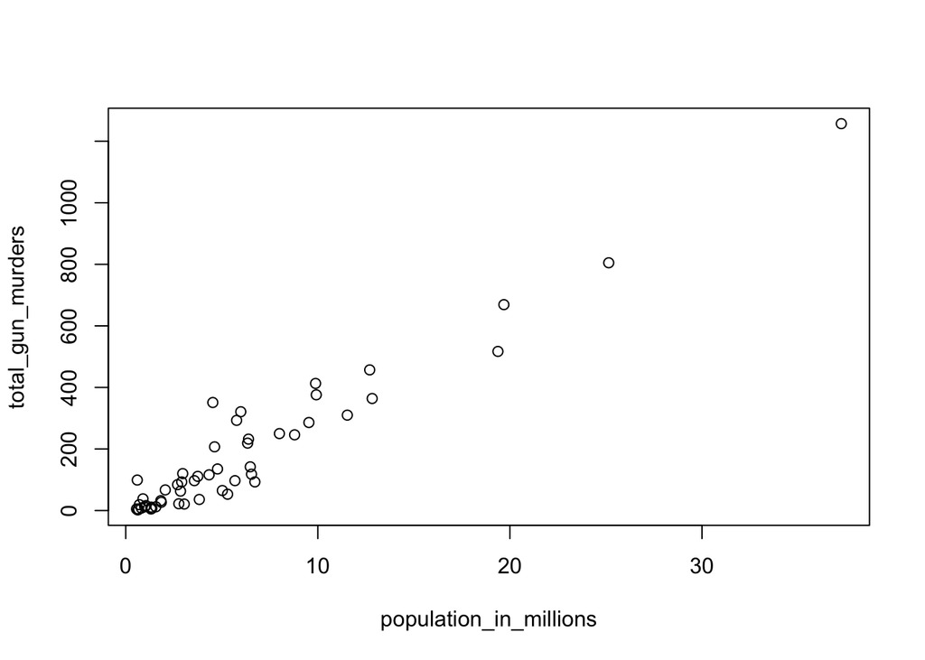

```r
library(dslabs)
data("murders")
population_in_millions <- murders$population/10^6
total_gun_murders <- murders$total
plot(population_in_millions, total_gun_murders)
```

We can clearly see a relationship. **Advanced**: For a quick plot that avoids accessing variables twice, we can use the `with` function

```r
with(murders, plot(population, total))
```

### Histograms

We will describe histograms as they related to distributions in the next chapter. Here we will simply note that histograms are a powerful graphical summary of a list of numbers that gives you a general overview of the types of values you have. We can make a histogram of our murder rates by simply typing

```r
library(dplyr)
```

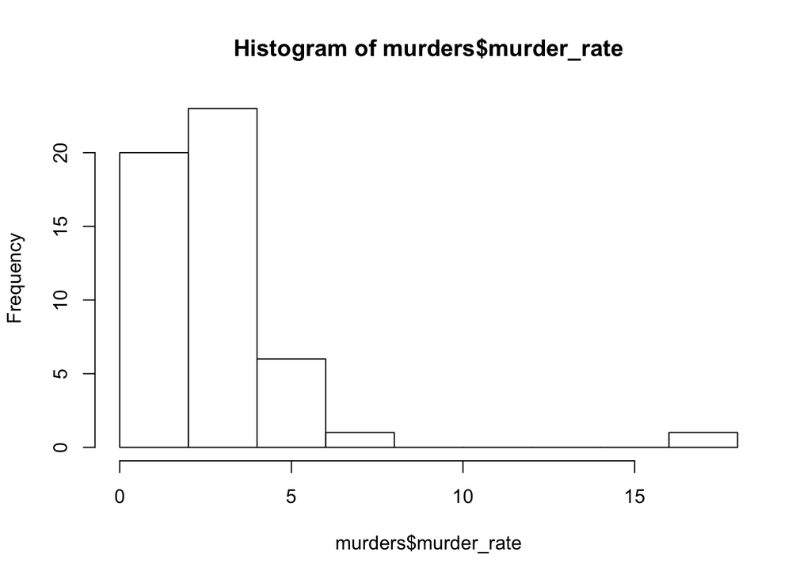

```r
murders <- mutate(murders, murder_rate = total / population * 100000)
hist(murders$murder_rate)
```

```r
murders$state[which.max(murders$murder_rate)]
```

```
## [1] "District of Columbia"
```

### Boxplot

Boxplots will be described in more detail in the next chapter as well. But here we say that they provide a more terse summary than the histogram but they are easier to stack with other boxplots. Here we can use them to compare the different regions

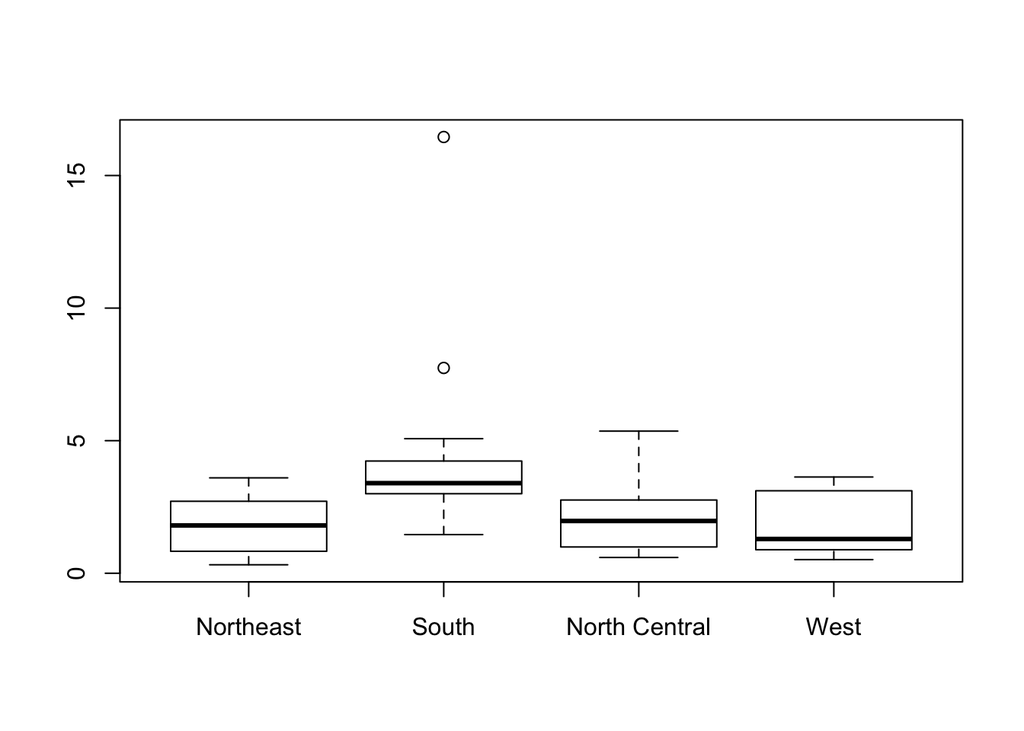

```r
boxplot(murder_rate~region, data = murders)
```

We can see that the South has larger murder rates than the other three regions.

### Assessment

1. We made a plot of total murders versus population and noted a strong relationship: not surprisingly, states with larger populations had more murders.

   ```r
   population_in_millions <- murders$population/10^6
   total_gun_murders <- murders$total
   plot(population_in_millions, total_gun_murders)
   ```

   Note that many states have populations below 5 million and are bunched up. We may gain further insights from making this plot in the log scale. Transform the variables using the `log10` transformation and then plot them.
2. Create a histogram of the state populations.
3. Generate boxplots of the state populations by region